# Implementasi Survival Analysis Pada Sistem Predictive Maintenance

Oleh: Fahim Hadi Maula

## Background

Sejak 2017 PEA telah menerapkan framework maintenance guna meningkatkan reliability plant Ciawi. Salah satu framewok yang digunakan adalah Reliability Centered Maintenance (RCM).

RCM memiliki 4 pilar utama:

- Predictive Maintenance
- Preventive Maintenance
- Reactive Maintenance
- Proactive Maintenance

Predictive maintenance saat ini dilakukan oleh seorang Inspector dengan metode pengambilan data telemetry berupa vibrasi, temperature, arus/tegangan listrik secara periodik. Kemudian data tersebut dianalisa untuk mengetahui kondisi terkini dari sebuah mesin. Inspector dapat memberikan feedback kepada Planner dan T2 untuk dilakukan follow up perbaikan sebelum sebuah mesin terjadi breakdown. Metode ini biasa dikenal dengan Condition Based Maintenance. Metode lain dapat dilakukan dengan model statistik, salah satunya Survival Analysis atau Time-to-event Analysis.

Lukasz Sobaszek, Arkadisz Gola (2016) menyebutkan dengan menambahkan konsep *predictive* pada penjadwalan maintenance akan membuat sistem yang lebih *robust*. Yang artinya fleksibilitas jadwal akan meningkat dalam merespon feedback analisa (predictive-reactive concept).

Big Data Republic merilis dalam blog resminya bagaimana predictive maintenance diimplementasikan disesuaikan dengan data yang dimiliki.

**Regression models to predict remaining useful lifetime (RUL)**

Strategi dengan model ini digunakan dengan tujuan menjawab pertanyaan: Berapa hari/siklus tersisa hingga mesin fail/rusak? Model ini dapat digunakan dengan support data history, setiap event tersedia (normal & failure). Pada event failure dilengkapi dengan kategori masing-masing failure.

```
Gap: data kondisi mesin saat running normal tidak tersedia. Belum tersedia platform untuk deploy model.
```

**Classification models to predict failure within a given time window**

Pertanyaan: Akankah mesin akan fail/rusak dalam N hari/siklus? Model ini membutuhkan support data yang sama dengan model RUL diatas.

```
Gap: data kondisi mesin saat running normal tidak tersedia. Belum tersedia platform untuk deploy model.
```

**Flagging anomalous behaviour**

Kedua strategi diatas membutuhkan banyak data history dengan label normal dan label fail/rusak. Tidak dapat diimplementasikan pada data yg unbalance, contoh: data kondisi pesawat. Tidak dibenarkan untuk membiarkan sebuah pesawat rusak di angkasa untuk kegiatan data collecting. Sehingga model ini digunakan untuk menjawab pertanyaan: Apakah perilaku (trend) yang ditunjukkan normal? Deteksi abnormality akan membantu team maintenance mengambil sebuah keputusan/action.

```
Gap: data yang dimiliki engineering unbalance tetapi dengan kondisi yang terbalik. Data fail/rusak jauh lebih banyak daripada data normal (bahkan tidak ada).
```

**Survival models for the prediction of failure probability over time**

Model terakhir akan memberikan informasi resiko dalam bentuk failure probability. Support data yang diperlukan adalah history data kerusakan dan info waktu kerusakan (event). Model ini cocok untuk menjawab pertanyaan: Berapa peluang x untuk survive setelah n jam/hari/siklus?

```
Gap: -
```

## Libraries

```python
# pandas for data management
import pandas as pd

# os for manipulating path
import os
from os.path import join

# script for download dataset
from scripts.download_dataset import download

# script for transform dataset
from scripts.transform_dataset import transurv

# script for survival curve
from scripts.curve_gen import surv_curve
from scripts.curve_gen import surv_curve_wg

# seaborn and matplotlib for data visualization
import seaborn as sns
import matplotlib.pyplot as plt

# setting report page and widget
import ipywidgets as wg
from IPython.display import display, HTML

# lifelines for Survival Modelling: non-parametric model
from lifelines import KaplanMeierFitter

# magic command
%matplotlib inline
```

## Censored Event

Dalam analisa berikut terdapat 2 observasi: survive dan not-survive (namanya juga survival analysis :p). Yang perlu didefinisikan terlebih dahulu adalah: mesin yang survive artinya mesin tersebut beroperasi normal tanpa terjadi kegagalan/rusak yang ditandai dengan terbitnya WO-PJOL.

Dataset diambil dari dua data yang dimiliki oleh PEA-Fillpack B untuk mesin filling:

- reportportal - Data_Mentah
- PWK mesin filling

Data_Mentah diambil untuk rentang 1 Oktober 2018 hingga tanggal report ini di running. Sementara PWK mesin filling di generate secara manual, secara lengkap (masih) hingga bulan April.

Penentuan rentang waktu observasi akan mempengaruhi perhitungan runhour kumulatif pada data. *Right censored data* digunakan sehingga data/event yang terjadi sebelum waktu observasi akan diabaikan.

```python
# call dataset
url = "http://maula.fahim:password@reportportal/Reports/Pages/Folder.aspx?ItemPath=%2f99.+Aplikasi+lain-lain%2f04.Aplikasi+Manufacturing%2fPortal+Engineering%2fWork+Order&ViewMode=List"
download(url=url)

# read dataset and getting data in the right format
history = join(os.getcwd(), 'datasets', 'filling_event.csv')
machine = join(os.getcwd(), 'datasets', 'machine.csv')
ttf = transurv(hist_url=history, mach_url=machine)
```

```python
%%html
<style>
table {float:left}
</style>
```

Kedua dataset yang didapat di transform sehingga menjadi data dengan format berikut:

| Column | Remark |
| --- | --- |
| id | ID mesin pada portalengineering |
| name | nama mesin yang dikenal user |
| runhour_cum | Runhour kumulatif (jam) hingga menemui sebuah kerusakan (event) |
| event | 1 = failure; 0 = no-failure |
| fail_type | kategori kerusakan |

```python
ttf.head()
```

|  | id | name | runhour_cum | event | fail_type |
| --- | --- | --- | --- | --- | --- |
| 0 | Filling Botol FBT1003 | F MATEERBURT AA | 2.083333 | 1 | Part tidak sesuai |
| 1 | Filling Botol FBT1003 | F MATEERBURT AA | 10.666667 | 0 | nofail |
| 2 | Filling 6 Line F6L1005 | F OMAG 6LINE AA | 9.500000 | 1 | Part rusak |
| 3 | Filling 6 Line F6L1005 | F OMAG 6LINE AA | 88.333333 | 1 | Part rusak |
| 4 | Filling 6 Line F6L1005 | F OMAG 6LINE AA | 7.000000 | 1 | Part rusak |

## EDA: Histogram

Visualisasi data dengan histogram untuk mengetahui persebaran data pada masing-masing mesin.

```python
%matplotlib inline

CSS = """div.output_area img {max-width:None !important;max-height: None !important";}"""
display(HTML('<style>{}</style>'.format(CSS)))
```

[figure not shown]

```python
sns.set(style="ticks")
g = sns.FacetGrid(ttf, col='name')
g.map(plt.hist, 'runhour_cum', bins=10)
```

## Survival Curve Estimation

Terdapat beberapa metode yang dapat digunakan pada survival analysis.

- Non-parametric model: Kaplan-Meier
- Semi-parametric model: Cox Proportional Hazard
- Parametric model: Weibull, LogNormal dll

Dalam analisa ini digunakan model Kaplan-Meier untuk estimasi. Formula yang digunakan oleh KM untuk estimasi sbb:

\begin{equation}\label{eq:} \hat{S}(t) = \Pi_{i:t_{i} \leq t} (1 - \frac{di}{ni}) \end{equation}

Untuk menerapkan formula diatas dalam sebuah model, digunakan fungsi **KaplanMeierFitter()** dari library bernama **lifelines**.

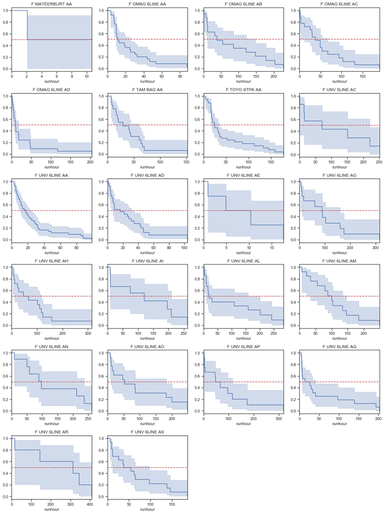

```python
T = ttf['runhour_cum']
E = ttf['event']

surv_curve(T, E, df=ttf, list=ttf['name'].unique())
```

Survival curve yang ditampilkan per mesin (dalam hal ini hanya mengambil mesin filling di PRB) memberikan gambaran performa mesin setelah *n* jam, hal ini dapat pula dikaitkan dengan *reliability* sebuah mesin. Saat *n=0* adalah saat mesin baru saja selesai diperbaiki. Mesin dengan performa rendah adalah mesin yang memiliki kurva yang curam. Untuk memudahkan dapat diambil sebuah garis di *y=0.5* dimana peluang survive dan fail sama-sama 50%. Semakin cepat kurva bertemu dengan garis ini, semakin buruk performa mesin.

Dalam kaitannya dengan predictive, planner/tim engineer lain dapat mendapatkan informasi: setelah berapa jam kerja mesin akan memiliki peluang kerusakan lebih besar daripada peluang survive? Sehingga planner dapat menerbitkan proposal untuk melakukan perbaikan sebelum terjadi kerusakan yang merugikan SCM.

Pertanyaan selanjutnya: langkah perbaikan seperti apa yang harus tim engineer lakukan agar memberikan dampak positif? Jika salah dalam mengambil langkah akan menyebabkan breakdown dan menyebabkan OFF mesin 2 kali (saat langkah perbaikan sebelum kerusakan dan saat terjadi kerusakan). Untuk menjawab kebutuhan ini, dibuatlah kategori penyebab kerusakan, diharapkan model yang didapatkan dapat menjadi dasar langkah perbaikan spesifik yang dibutuhkan pada mesin.

```python
dd = wg.Dropdown(options=[machine for machine in ttf['name'].unique()], value='F OMAG 6LINE AA', description='machine', disabled=False)
wg.interact(surv_curve_wg, value=dd)
```

```
<function scripts.curve_gen.surv_curve_wg(value)>
```

## Reference

https://medium.com/bigdatarepublic/machine-learning-for-predictive-maintenance-where-to-start-5f3b7586acfb